# Random Forest

# Tarea 5.

# Elaborada por: Karen Bolaños Alfaro

# Métodos Supervisados

Librerías

```r
library(caTools)
library(randomForest)
library(tibble)
library(GGally)
```

```r
library(visdat)
library(rpart)
library(rpart.plot)
library(ROCR)
```

1. Desarolle el Análisis del Problema

# Construya el análisis del problema

Cree 3 modelos de tipo supervisados para predecir si un hongo es comestible o no basado en el data set agaricus-lepiota.

Este conjunto de datos incluye descripciones de muestras hipotéticas correspondientes a 23 especies de hongos branquiales en el hongo de la familia Agaricus y Lepiota extraídas de la Guía de campo de la Sociedad Audubon de hongos de América del Norte (1981). Cada especie se identifica como definitivamente comestible, definitivamente venenosa o de comestibilidad desconocida y no se recomienda. Esta última clase se combinó con la venenosa. La Guía establece claramente que no existe una regla simple para determinar la comestibilidad de un hongo; ninguna regla como “folletos tres, que así sea” para el roble venenoso y la hiedra.

Fuente del dataset: https://archive.ics.uci.edu/ml/machine-learning-databases/mushroom/agaricus-lepiota.data

1. Cargue el archivo agaricus_lepiota.data.csv en una variable
- EL atributo Stalk Root tiene 2480 valores faltantes representados por ?. Que hacer con ellos? Reemplazarlos por NA al cargar el arhivo

```r
hongos_df <- read.csv("datos/expanded", header = F, col.names = c("class", "cap_shape", "cap_surface", "cap_color", "bruises", "odor", "gill_attachment", "gill_spacing", "gill_size", "gill_color", "stalk_shape", "stalk_root", "stalk_surface_above_ring", "stalk_surface_below_ring", "stalk_color_above_ring", "stalk_color_below_ring", "veil_type", "veil_color", "ring_number", "ring_type", "spore_print_color", "population", "habitat"), na.strings = '?')
```

```r
# ver los tipos de datos
glimpse(hongos_df)
```

```
## Observations: 8,416
## Variables: 23
## $ class                    <fct> EDIBLE, EDIBLE, EDIBLE, EDIBLE, EDIBLE,…
## $ cap_shape                <fct> CONVEX, CONVEX, CONVEX, CONVEX, CONVEX,…
## $ cap_surface              <fct> SMOOTH, SMOOTH, SMOOTH, SMOOTH, SMOOTH,…
## $ cap_color                <fct> WHITE, WHITE, WHITE, WHITE, WHITE, WHIT…
## $ bruises                  <fct> BRUISES, BRUISES, BRUISES, BRUISES, BRU…
## $ odor                     <fct> ALMOND, ALMOND, ALMOND, ALMOND, ALMOND,…
## $ gill_attachment          <fct> FREE, FREE, FREE, FREE, FREE, FREE, FRE…
## $ gill_spacing             <fct> CROWDED, CROWDED, CROWDED, CROWDED, CRO…
## $ gill_size                <fct> NARROW, NARROW, NARROW, NARROW, NARROW,…
## $ gill_color               <fct> WHITE, WHITE, PINK, PINK, BROWN, BROWN,…
## $ stalk_shape              <fct> TAPERING, TAPERING, TAPERING, TAPERING,…
## $ stalk_root               <fct> BULBOUS, BULBOUS, BULBOUS, BULBOUS, BUL…
## $ stalk_surface_above_ring <fct> SMOOTH, SMOOTH, SMOOTH, SMOOTH, SMOOTH,…
## $ stalk_surface_below_ring <fct> SMOOTH, SMOOTH, SMOOTH, SMOOTH, SMOOTH,…
## $ stalk_color_above_ring   <fct> WHITE, WHITE, WHITE, WHITE, WHITE, WHIT…
## $ stalk_color_below_ring   <fct> WHITE, WHITE, WHITE, WHITE, WHITE, WHIT…
## $ veil_type                <fct> PARTIAL, PARTIAL, PARTIAL, PARTIAL, PAR…
## $ veil_color               <fct> WHITE, WHITE, WHITE, WHITE, WHITE, WHIT…
## $ ring_number              <fct> ONE, ONE, ONE, ONE, ONE, ONE, ONE, ONE,…
## $ ring_type                <fct> PENDANT, PENDANT, PENDANT, PENDANT, PEN…
## $ spore_print_color        <fct> PURPLE, BROWN, PURPLE, BROWN, PURPLE, B…
## $ population               <fct> SEVERAL, SEVERAL, SEVERAL, SEVERAL, SEV…
## $ habitat                  <fct> WOODS, WOODS, WOODS, WOODS, WOODS, WOOD…
```

2. Desarolle el Entendimiento de los Datos

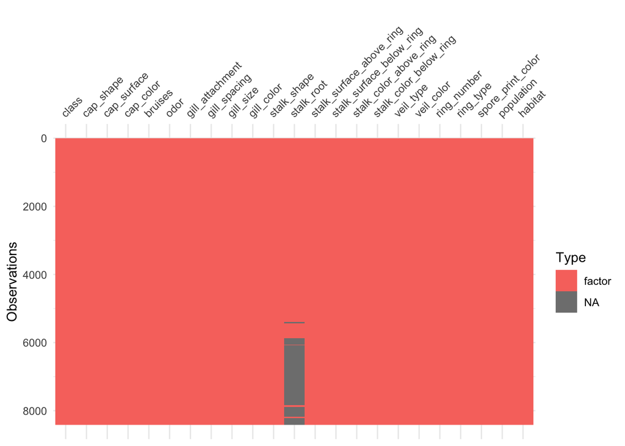

```r
# todas las observaciones son de tipo factor
vis_dat(hongos_df)
```

3. Utilizando barplot cree un gráfico de los atributos del dataset, observe las correlaciones entre atributos
- Barploot de cada una de las observaciones

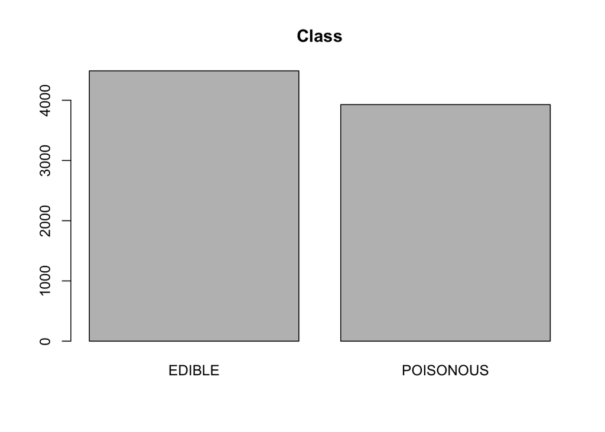

```r
barplot(table(hongos_df$class), main = "Class")
```

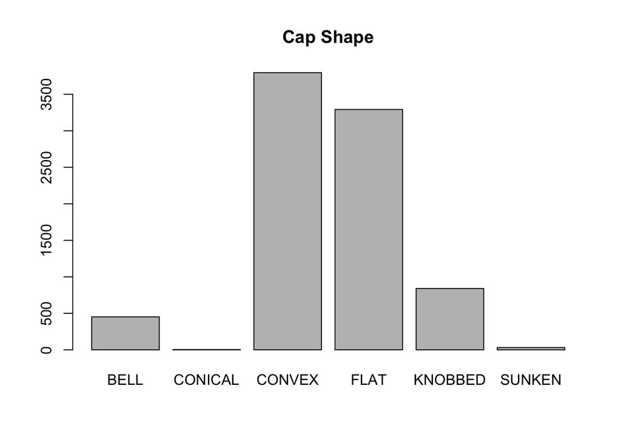

```r
barplot(table(hongos_df$cap_shape), main = "Cap Shape")
```

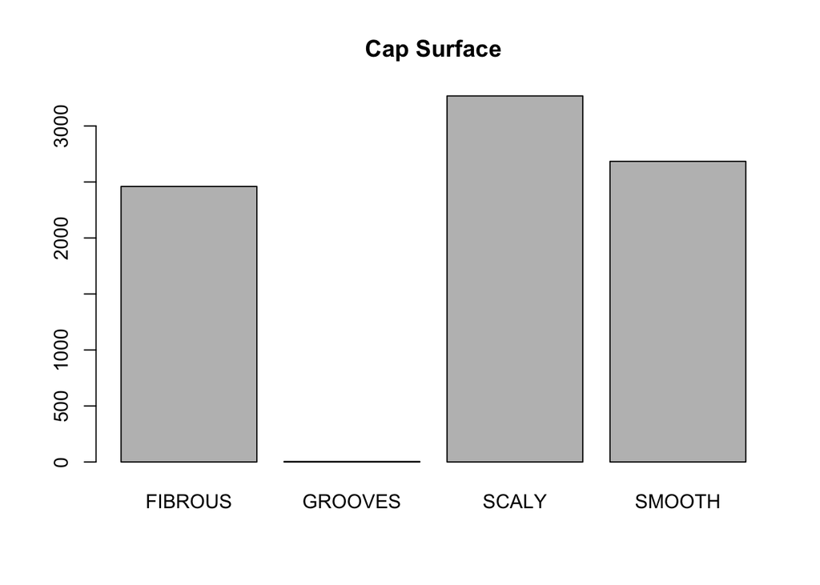

```r
barplot(table(hongos_df$cap_surface), main = "Cap Surface")
```

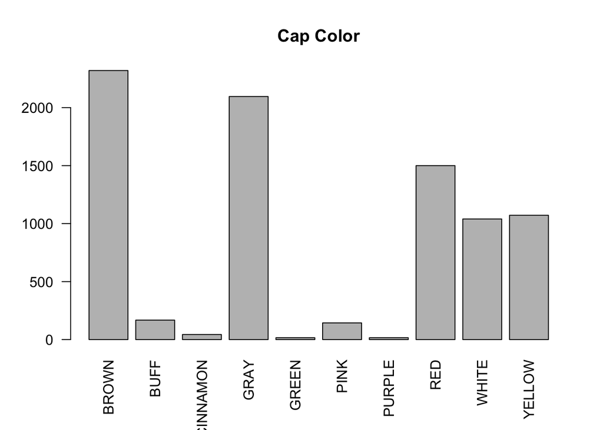

```r
barplot(table(hongos_df$cap_color), main = "Cap Color", las = 2)
```

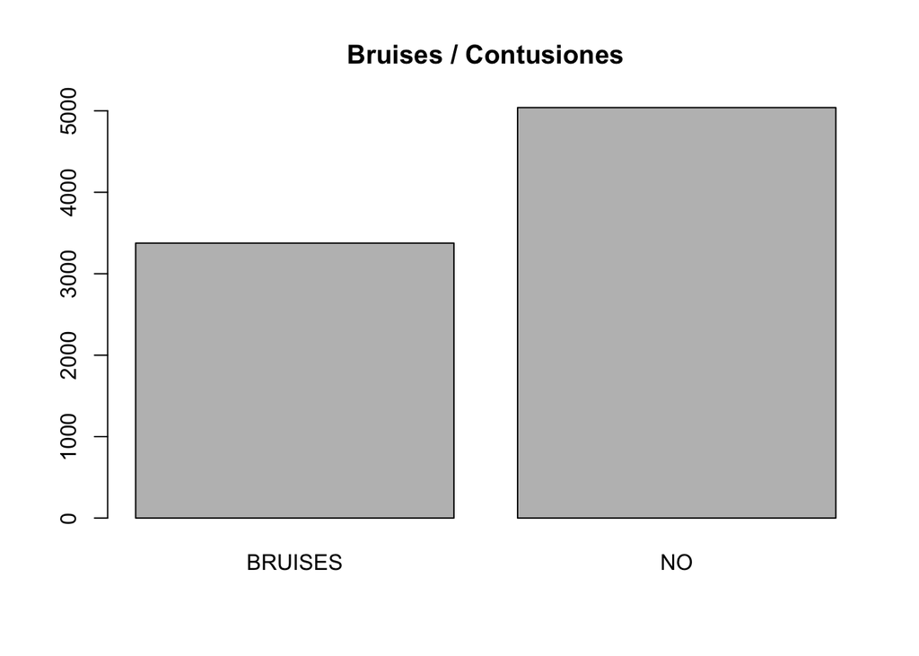

```r
barplot(table(hongos_df$bruises), main = "Bruises / Contusiones")
```

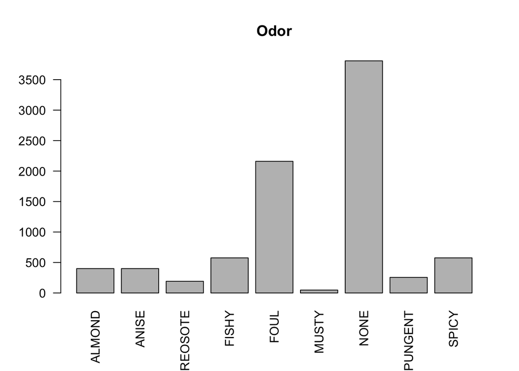

```r
barplot(table(hongos_df$odor), main = "Odor", las = 2)
```

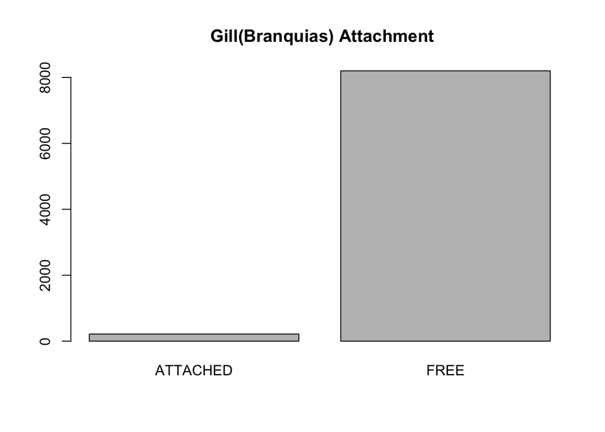

```r
barplot(table(hongos_df$gill_attachment), main = " Gill(Branquias) Attachment")
```

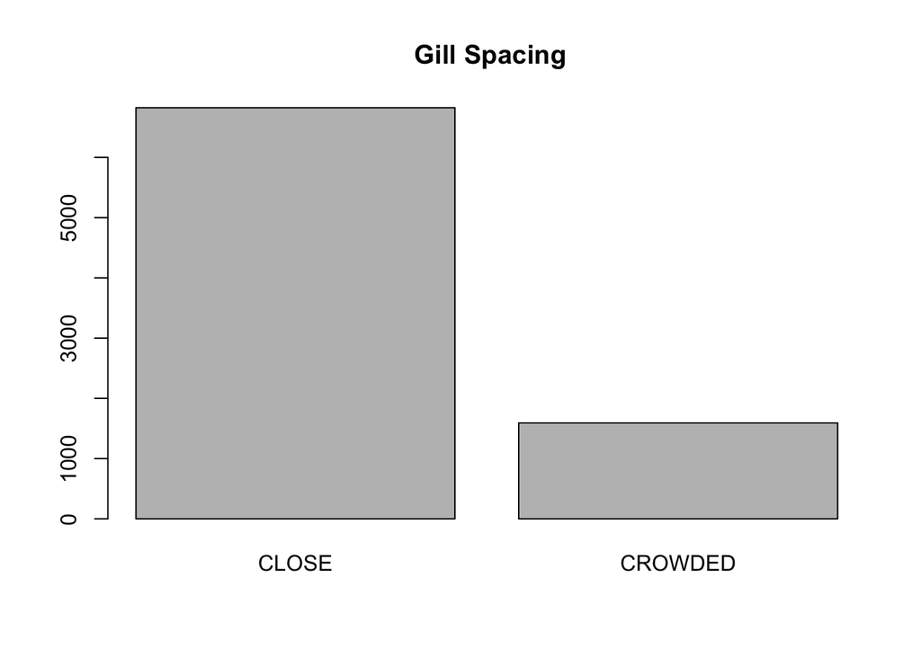

```r
barplot(table(hongos_df$gill_spacing), main = " Gill Spacing")
```

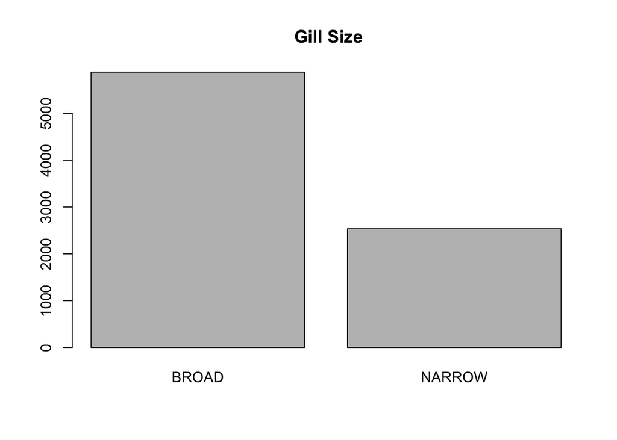

```r
barplot(table(hongos_df$gill_size), main = " Gill Size")
```

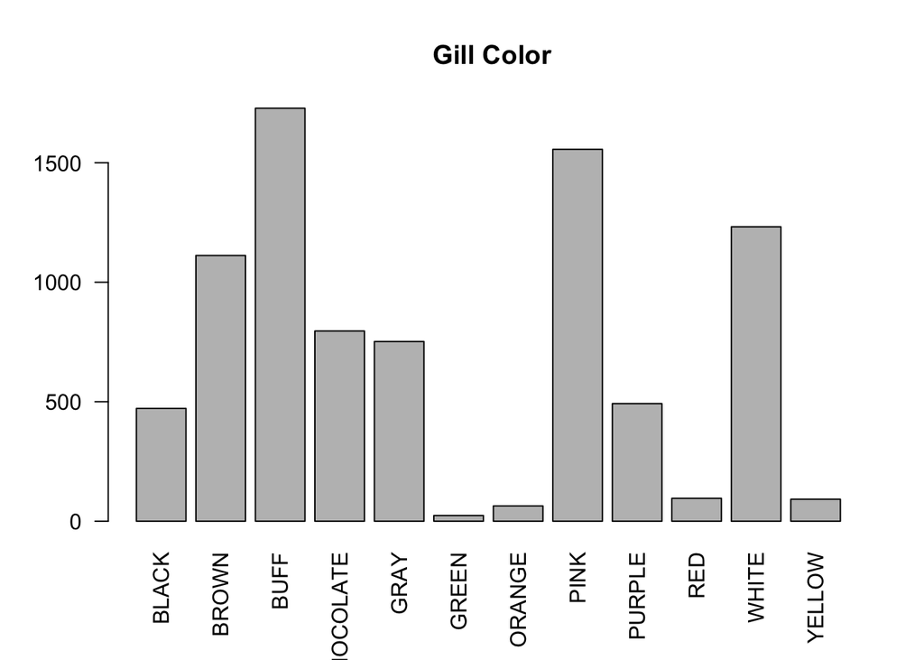

```r
barplot(table(hongos_df$gill_color), main = " Gill Color", las = 2)
```

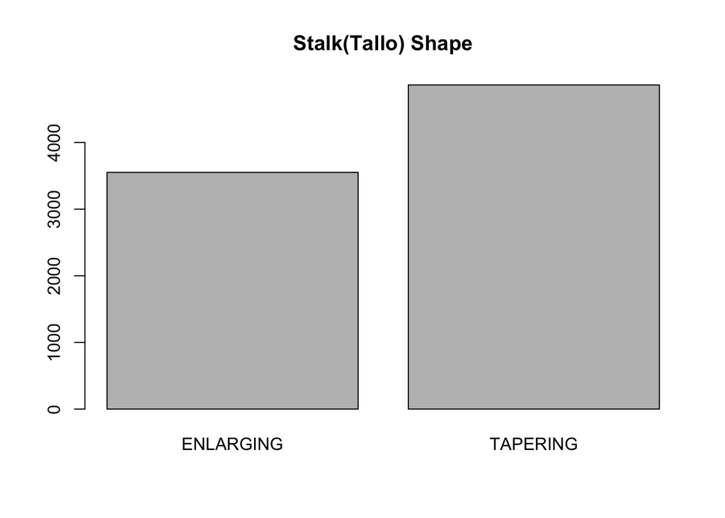

```r
barplot(table(hongos_df$stalk_shape), main = "Stalk(Tallo) Shape")
```

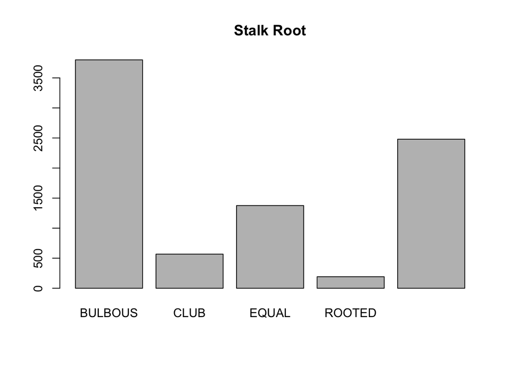

```r
barplot(table(hongos_df$stalk_root, useNA = "ifany"), main = "Stalk Root")
```

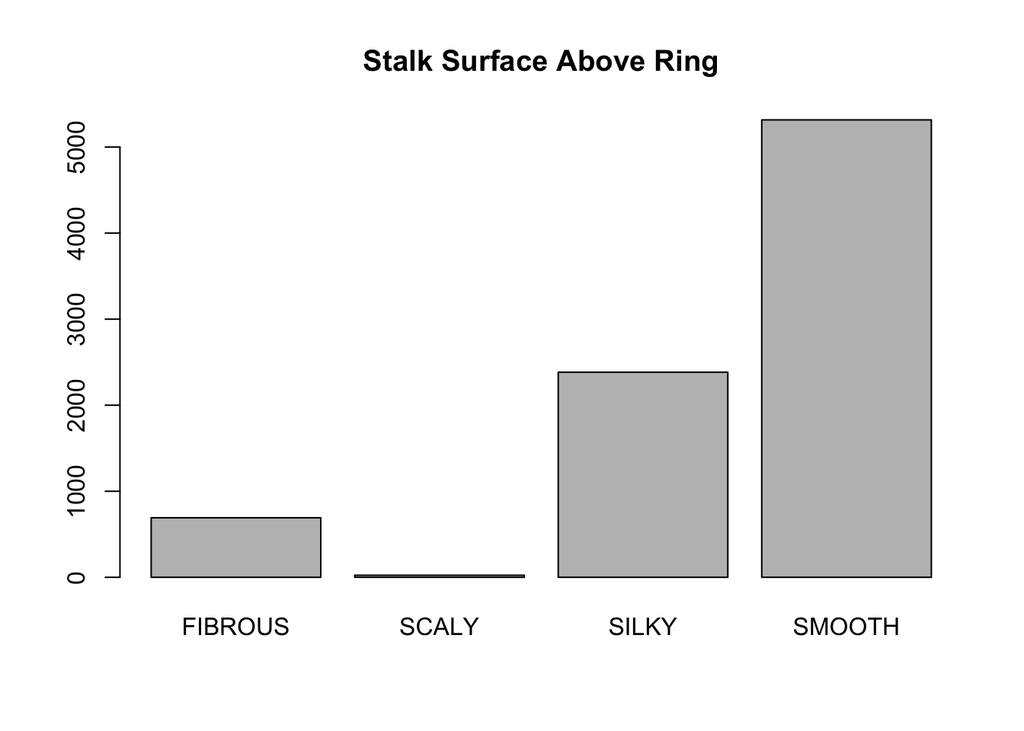

```r
barplot(table(hongos_df$stalk_surface_above_ring), main = "Stalk Surface Above Ring")
```

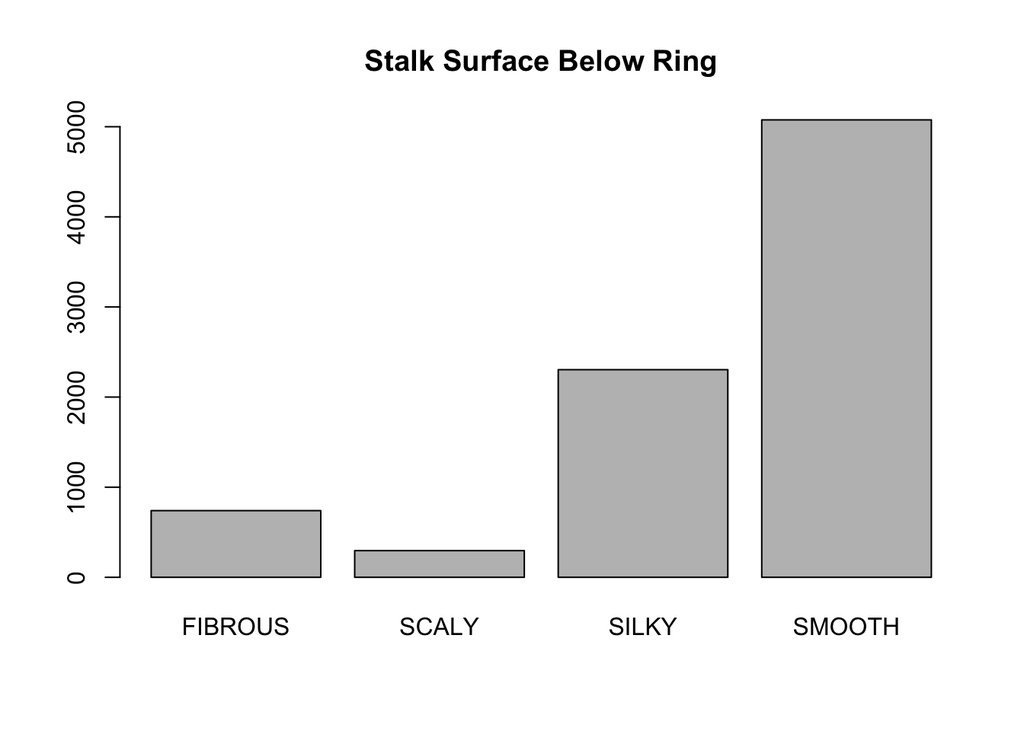

```r
barplot(table(hongos_df$stalk_surface_below_ring), main = "Stalk Surface Below Ring")
```

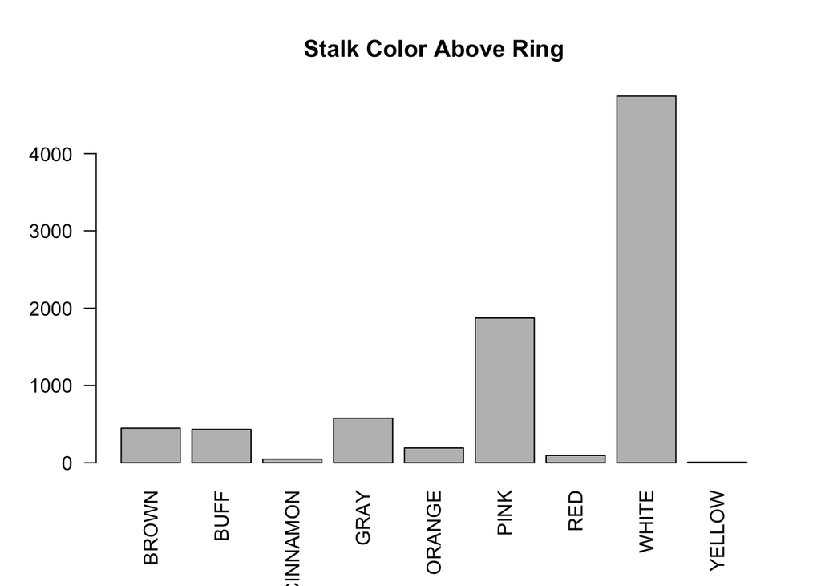

```r
barplot(table(hongos_df$stalk_color_above_ring), main = "Stalk Color Above Ring", las = 2)
```

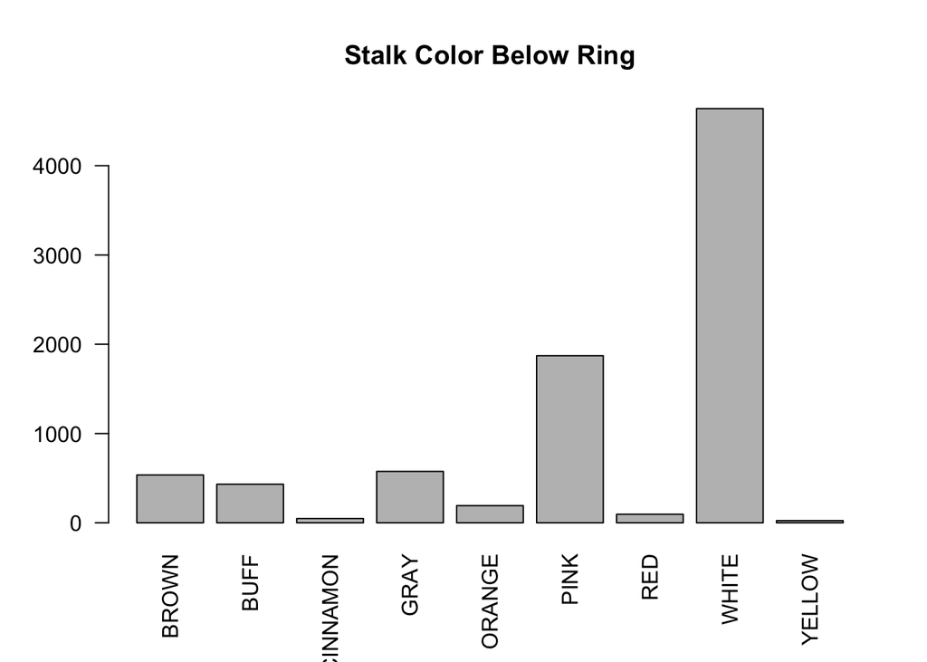

```r
barplot(table(hongos_df$stalk_color_below_ring), main = "Stalk Color Below Ring", las = 2)
```

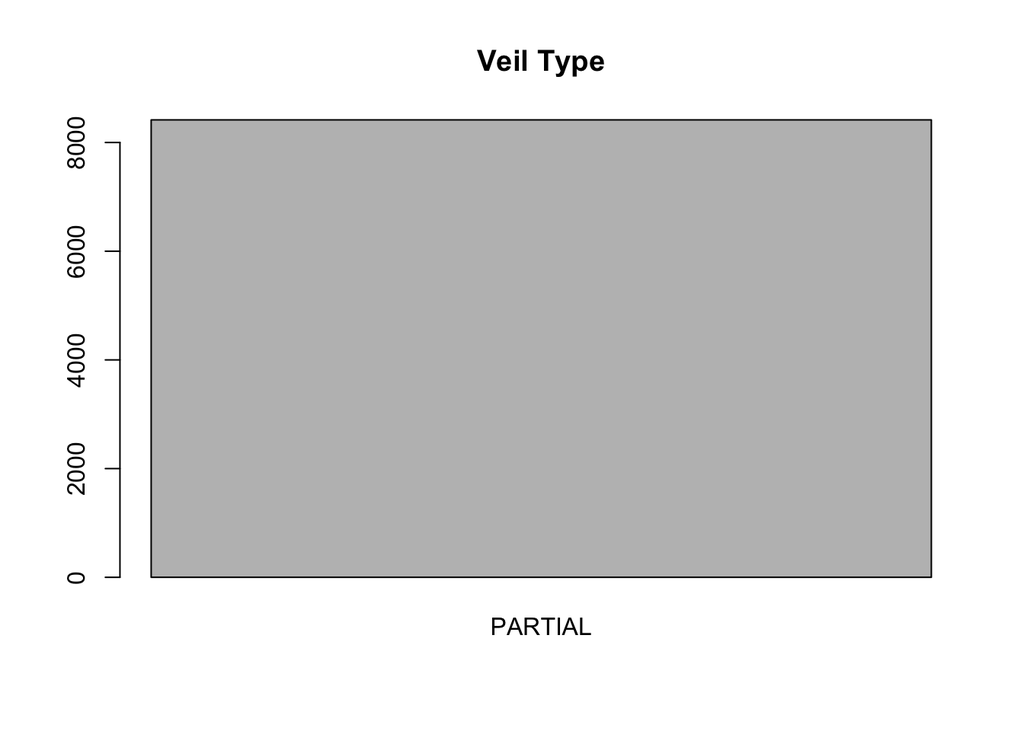

```r
barplot(table(hongos_df$veil_type), main = "Veil Type")
```

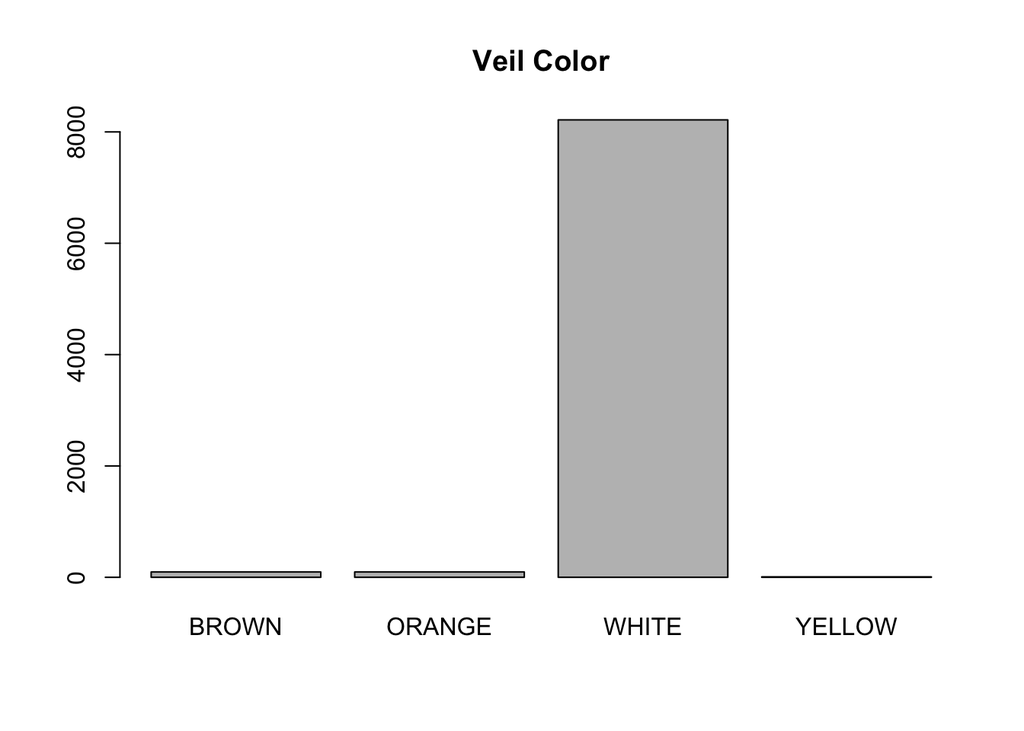

```r
barplot(table(hongos_df$veil_color), main = "Veil Color")
```

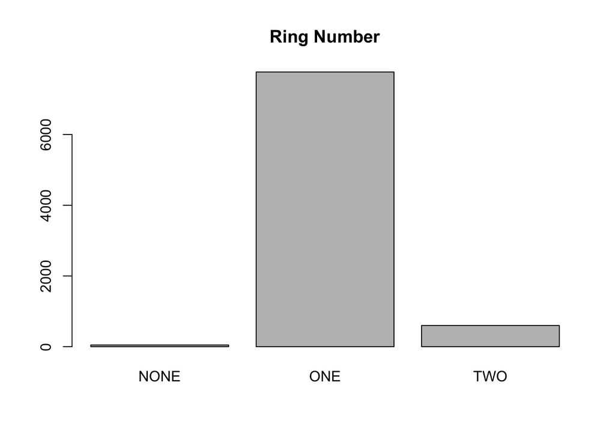

```r
barplot(table(hongos_df$ring_number), main = "Ring Number")
```

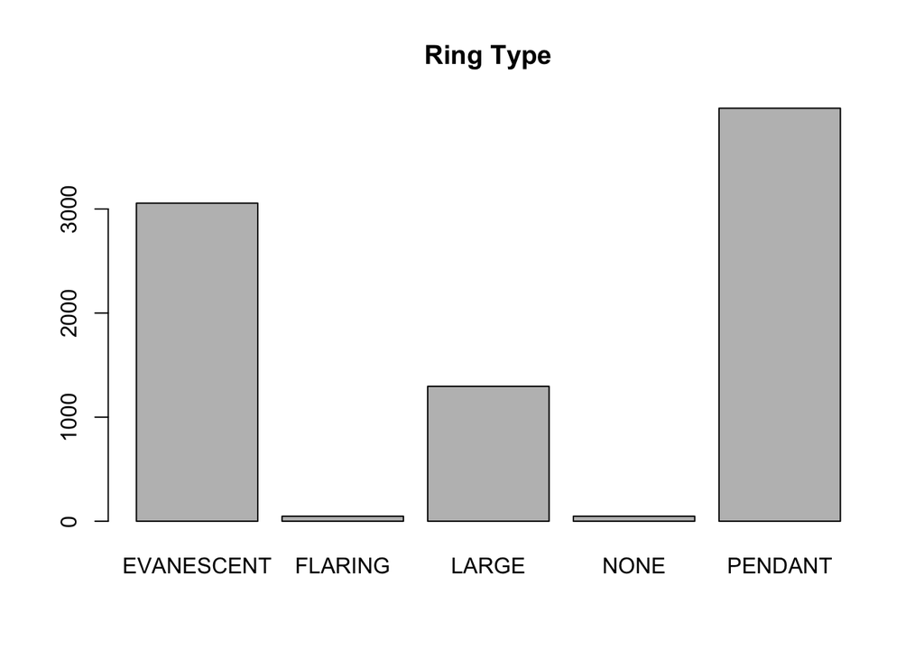

```r
barplot(table(hongos_df$ring_type), main = "Ring Type")
```

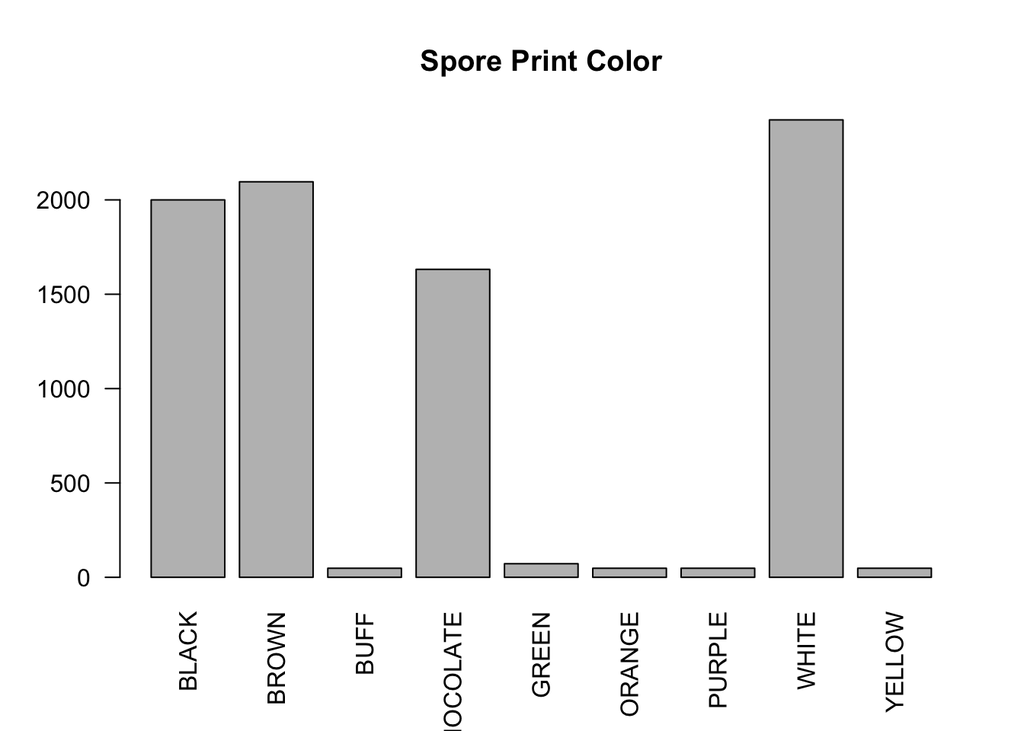

```r
barplot(table(hongos_df$spore_print_color), main = "Spore Print Color", las = 2)
```

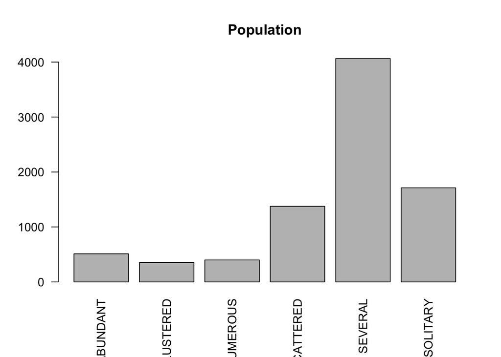

```r
barplot(table(hongos_df$population), main = "Population", las = 2)
```

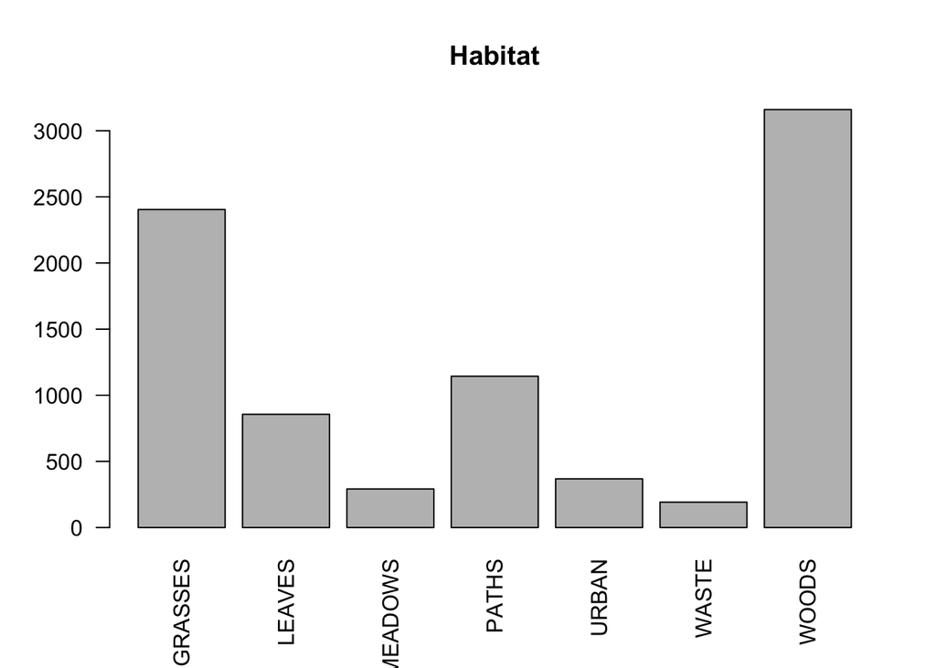

```r
barplot(table(hongos_df$habitat), main = "Habitat", las = 2)
```

4. Realice al menos 3 modelos vistos en clase

```r
# division de los datos en training y prueba
set.seed(1710)

splt <- sample.split(hongos_df$class, SplitRatio = 0.7)

hongos_entrenamiento <- hongos_df[splt,]
hongos_prueba <- hongos_df[!splt,]

# comprobar que seguimos teniendo el mismo numero de observaciones
nrow(hongos_entrenamiento) + nrow(hongos_prueba)
```

```
## [1] 8416
```

## Modelo #1: Crear el modelo de árboles de decisión

- Hacemos el modelo con todas las variables del dataset

```r
modelo_arbol <- rpart(class ~ ., data = hongos_entrenamiento, method =  'class')
```

Una vez creado el modelo se hacen las predicciones

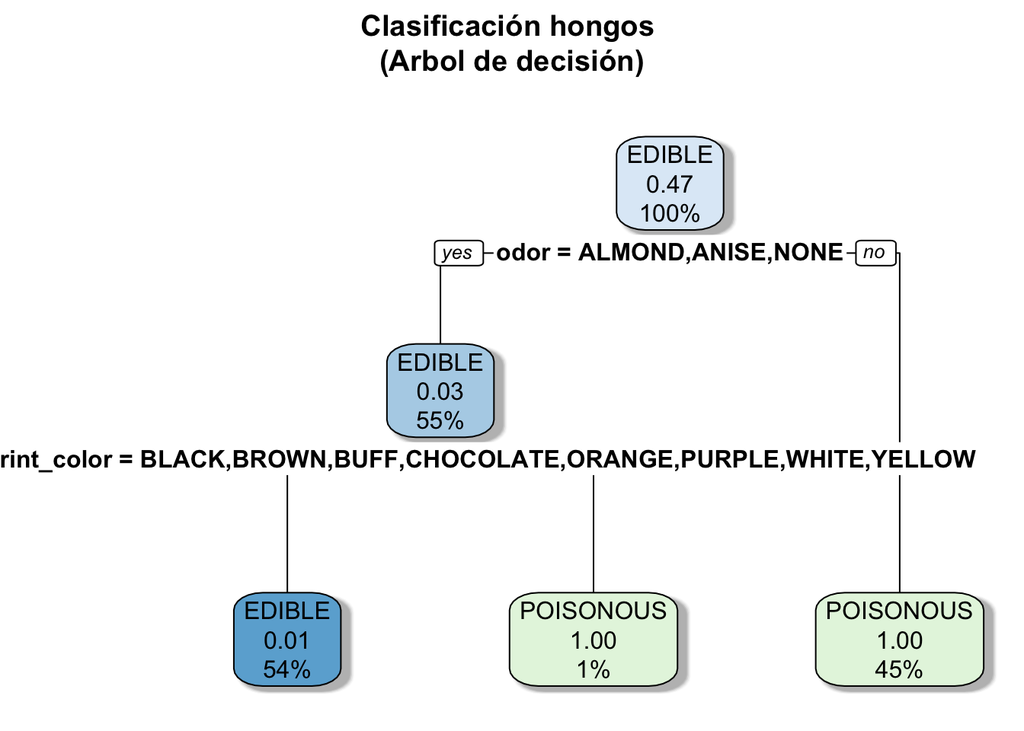

```r
# predecir utilizando el conjunto de datos de prueba
# en estas predicciones se obtiene la probabilidad
predicciones <- predict(modelo_arbol, newdata = hongos_prueba, type = 'prob')

rpart.plot(modelo_arbol,
           shadow.col = "gray", #Agregar sombras
           main = "Clasificación hongos \n(Arbol de decisión)\n")
```

```r
# aqui vemos la probabilidad en la prediccion de que un hongo sea o comestible o no
head(predicciones)
```

```
##       EDIBLE POISONOUS
## 5  0.9877397 0.0122603
## 7  0.9877397 0.0122603
## 9  0.9877397 0.0122603
## 19 0.9877397 0.0122603
## 21 0.9877397 0.0122603
## 24 0.9877397 0.0122603
```

Hacer una matriz de confusión para ver las predicciones, en el paso anterior se ejecutó el método predict para que nos diera la probabilidad, ahora se hace con class para que nos retorne la clase predicha

```r
predicciones <- predict(modelo_arbol, newdata = hongos_prueba, type = 'class')

data <- table(hongos_prueba$class, predicciones)
print(data)
```

```
##            predicciones
##             EDIBLE POISONOUS
##   EDIBLE      1346         0
##   POISONOUS      9      1169
```

ROC del modelo árboles de decisión

```r
prediccionesROC = prediction(c(predicciones), c(hongos_prueba[,'class']))
as.numeric(performance(prediccionesROC, "auc")@y.values)
```

```
## [1] 0.99618
```

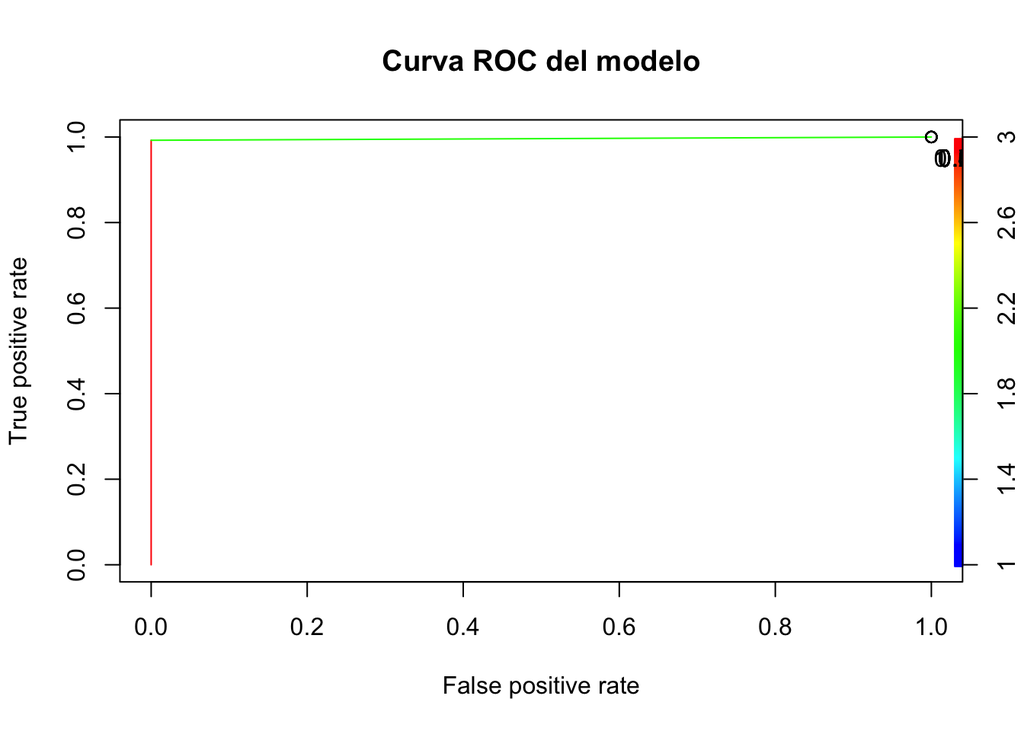

```r
plot(performance(prediccionesROC, "tpr", "fpr"),
colorize = T,
print.cutoffs.at = seq(0,1,by = 0.1),
text.adj = c(-0.2,1.7),
main = 'Curva ROC del modelo')
```

El 99.6% de las predicciones fueron correctas, lo cual quiere decir que es un modelo muy bueno.

## Modelo #2: Bosques Aleatorios

```r
modelo_bosque <- randomForest(class ~ .,
                              na.action = na.omit,
                              data = hongos_entrenamiento)
```

```r
# realizar predicciones
predicciones_bosque <- predict(modelo_bosque, newdata = hongos_prueba, type = 'class')

# matriz de confusión
data_bosque <- table(hongos_prueba$class, predicciones_bosque)
print(data_bosque)
```

```
##            predicciones_bosque
##             EDIBLE POISONOUS
##   EDIBLE      1148         0
##   POISONOUS      0       637
```

```r
prediccionesROC = prediction(c(predicciones_bosque), c(hongos_prueba[,'class']))
as.numeric(performance(prediccionesROC, "auc")@y.values)
```

```
## [1] 1
```

## Modelo #3: Regresión Logística

**Definición:** En estadística, la regresión logística es un tipo de análisis de regresión utilizado para predecir el resultado de una variable categórica (una variable que puede adoptar un número limitado de categorías) en función de las variables independientes o predictoras.

```r
modelo_reg_log = glm(class ~ cap_color + cap_surface + cap_shape + habitat,
                     data = hongos_entrenamiento,
                     family = binomial)
```

Predicciones

```r
predicciones_reg_log <- predict(modelo_reg_log, newdata = hongos_prueba, type = 'response')

data_reg_log <- table(hongos_prueba$class, predicciones_reg_log >= 0.5)
print(data_reg_log)
```

```
##
##             FALSE TRUE
##   EDIBLE     1167  179
##   POISONOUS   397  781
```

```r
prediccionesROC = prediction(c(predicciones_reg_log), c(hongos_prueba[,'class']))
as.numeric(performance(prediccionesROC, "auc")@y.values)
```

```
## [1] 0.8480715
```

Exactitud del modelo

```r
print((data_reg_log[1,1] + data_reg_log[2,2]) / sum(data_reg_log) )
```

```
## [1] 0.7717908
```

Obtenemos un modelo con exactitud del 77.17% para la combinación de variables elegidas. Puede mejorar este valor si se prueba con otra combinación de variables.